# A Simulation Study

## map color on variable

3. Extending the plot from question 1 (i.e., using the object `p1`), map the color of the points to the variable `cut`. Use `geom_rug` to visualize the marginal distributions of the two variables (`carat` and `price`). Also, add a legend at the top of your plot and set its title to “Cut quality”.

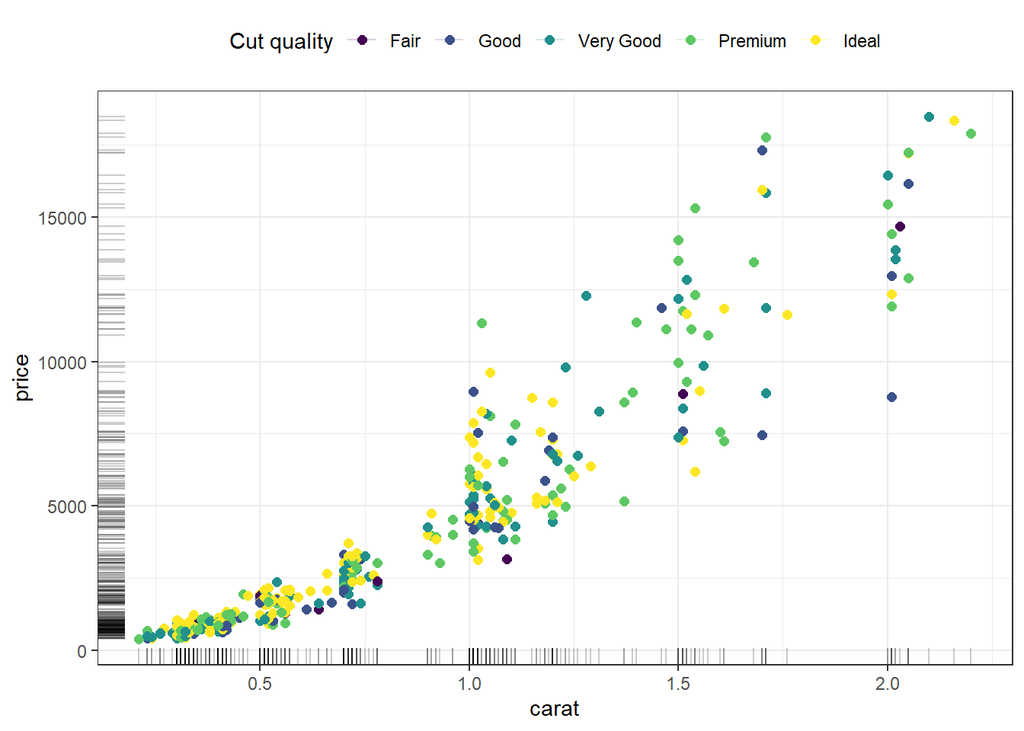

```r
p1 <- ggplot(diamonds2) +
  aes(x = carat, y = price) +
  geom_point(size = 2) +
# on ajoute ça
  aes(col = cut) +
  geom_rug(aes(col = NULL), alpha = 0.2) +
  theme(legend.position = "top") +
  labs(col = "Cut quality")
p1
```

## map with conditions

4. Extending the plot from question 1, map the shape and the color of the points to the indicator variable $I(depth>62.5)$, i.e., the binary variable taking values `TRUE` or `FALSE` according to whether $depth>62.5$ or not.

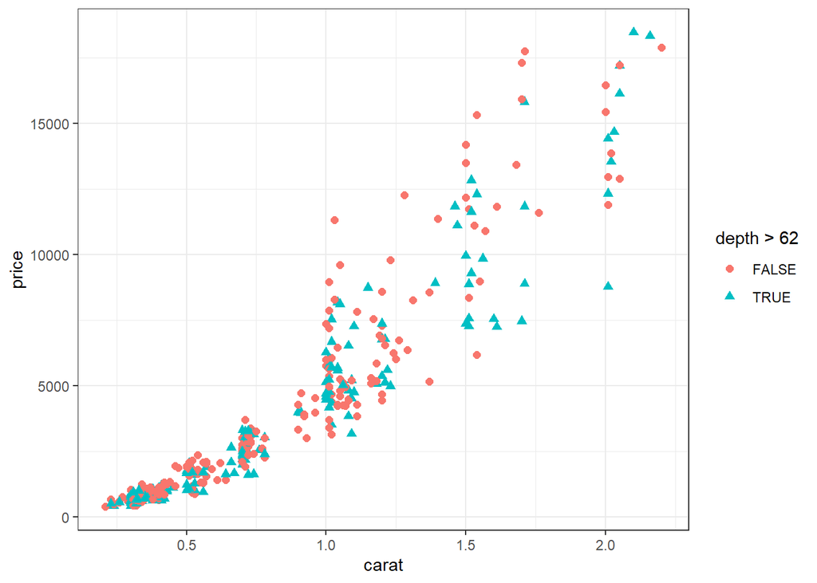

```r
p1 <- ggplot(diamonds2) +
  aes(x = carat, y = price) +
  geom_point(size = 2)
# on ajoute ça
p4 <- p1 +
  aes(shape = depth > 62, color = depth > 62)
p4
```

## add another layer

5. Extending the previous question, map the color of the points to the variable `cut`; keep the mapping between shape and $I(depth>62.5)$.

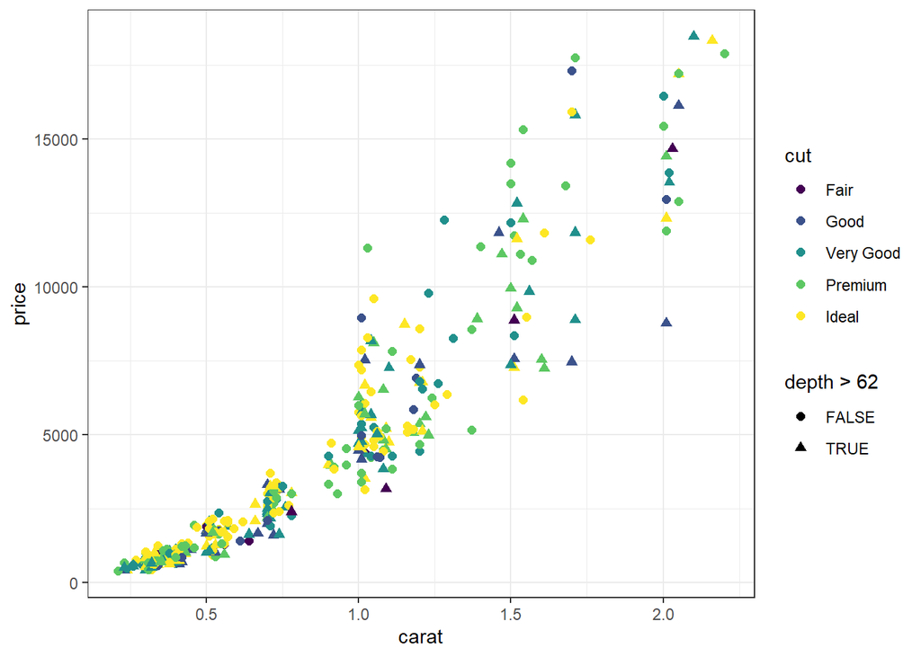

```r
p4 <- ggplot(diamonds2) +
  aes(x = carat, y = price) +
  geom_point(size = 2) +
  aes(shape = depth > 62, color = depth > 62)

p5 <- p4 +
  aes(color = cut)
p5
```

## add labels

6. Extending the previous question, add axis labels and title so that the resulting plot looks like this.

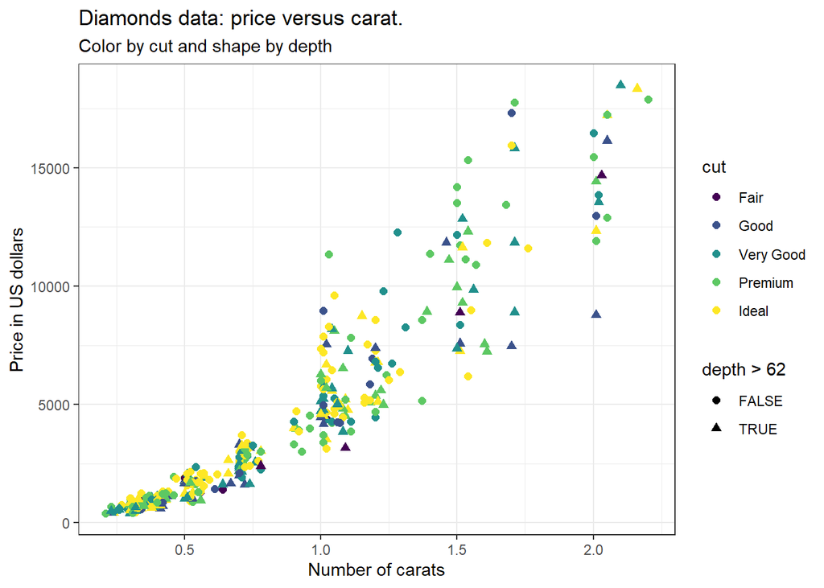

```r
p5 <- ggplot(diamonds2) +
  aes(x = carat, y = price) +
  geom_point(size = 2) +
  aes(shape = depth > 62) +
  aes(color = cut)

p5 + labs(title = "Diamonds data: price versus carat.",
          subtitle = "Color by cut and shape by depth",
          x = "Number of carats", y = "Price in US dollars")
```

# 3 Regression line

## two lines

7. Extending the plot from question 4, add two least-squares lines: one for `depth>62.5` and another for `depth<=62.5`. Your plot should not include any confidence-intervals.

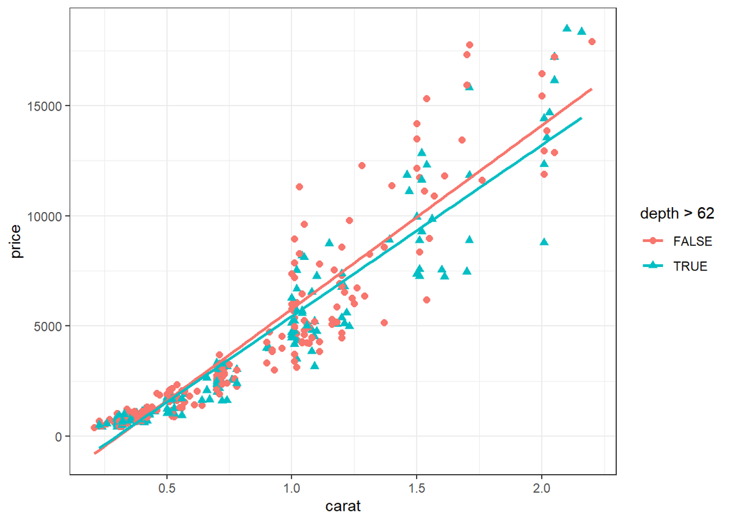

```r
p4 <- ggplot(diamonds2) +
  aes(x = carat, y = price) +
  geom_point(size = 2) +
  aes(shape = depth > 62, color = depth > 62)
p7 <- p4 +
  geom_smooth(method = "lm", se = FALSE) #SE is standard error
p7
```

## change lines type and colors

8. Same question as before but this time the two lines should have the same color but different line type. Hint: Use `aes(inetype = depth > 62)` within `geom_smooth`.

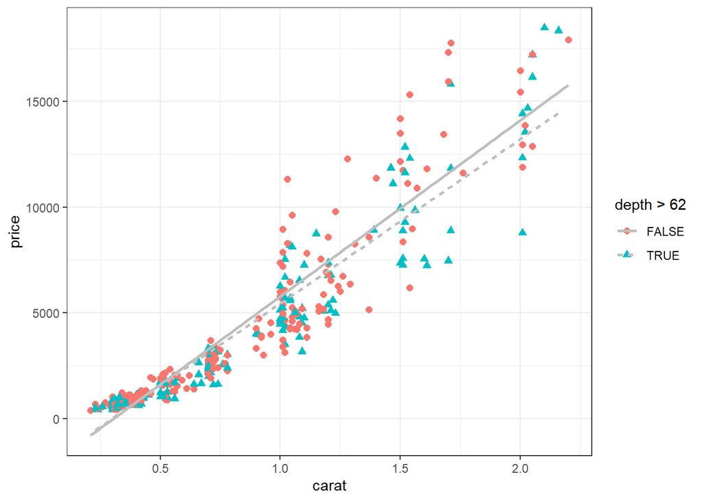

```r
p4 <- ggplot(diamonds2) +
  aes(x = carat, y = price) +
  geom_point(size = 2) +
  aes(shape = depth > 62, color = depth > 62)
p8 <- p4 +
  geom_smooth(method = "lm", se = FALSE,color = 'gray',
              aes(linetype = depth > 62))
p8
```

## adapt the point color

9. Extending the previous question, set the color of all the points to gray.

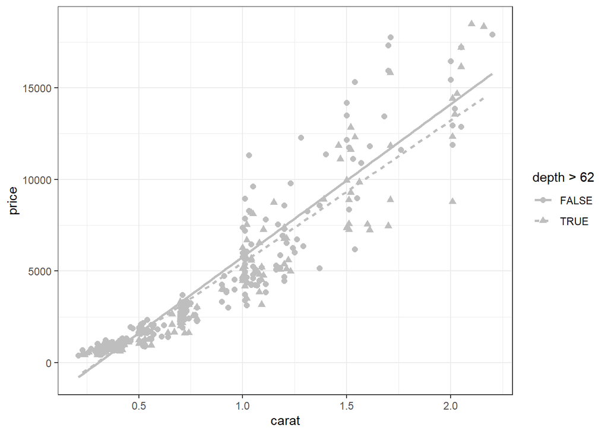

```r
p8 + geom_point(color = "gray", size = 2)
```

# 4 adapt regression lines

## only one line

10. Extending the plot from question 4, add one global least-squares line (without distinguishing `depth>62.5` and `depth<=62.5`). Your plot should not include any confidence-intervals.

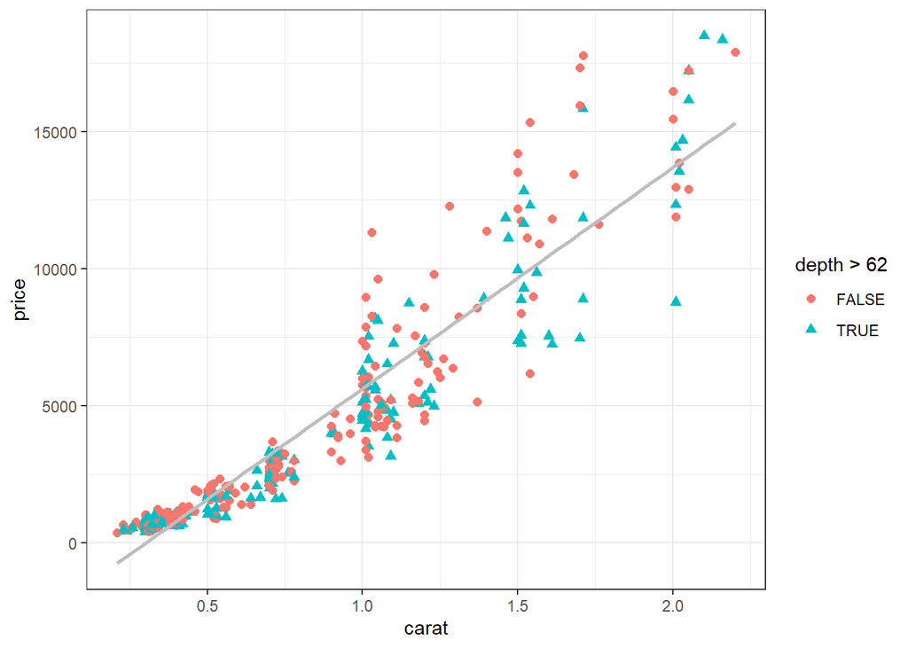

```r
p10 <- p4 +
  geom_smooth(method = "lm", se = FALSE, col = "gray", aes(shape = NULL))
p10
```

## linetype

11. Extending the plot of question 7, overlay the global least-squares line on top of your scatter plot. Your plot should look like this. Hint: Use `linetype = 3` within `geom_smooth`.

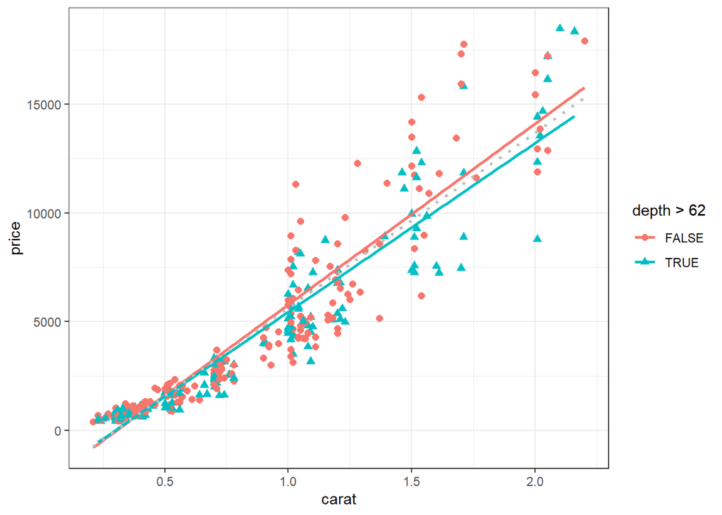

```r
p11 <- p7 +
  geom_smooth(method = "lm", se = FALSE, col = "gray", linetype = 3, aes(shape = NULL))
p11
```

# 5 Transformations of variables

## log

12. Redo the previous question but with `x=log10(carat)` and `y=log10(price)`.

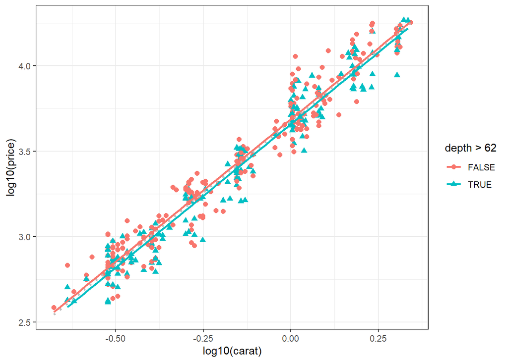

```r
p11 + aes(x = log10(carat), y = log10(price))
```

## Change window

13. Following from question 10, display only the region of the plot with $0.3\le carat \le 1$ and $1000\le price \le 10000$. Yous should visually zoom in this region without modifying the data. Hint: use `coord_cartesian`; more details [here](https://ggplot2.tidyverse.org/reference/coord_cartesian.html).

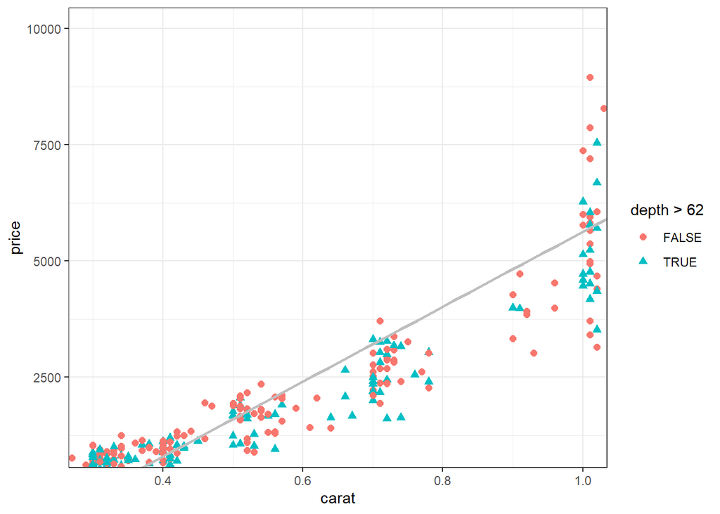

```r
p10 +
  coord_cartesian(x = c(0.3, 1), y = c(1000, 10000))
```

## plot only in window

14. The same question as before but, this time, you should remove all the data outside the provided limits (not only zooming in that region). Hint: use the ggplot function `lims`.

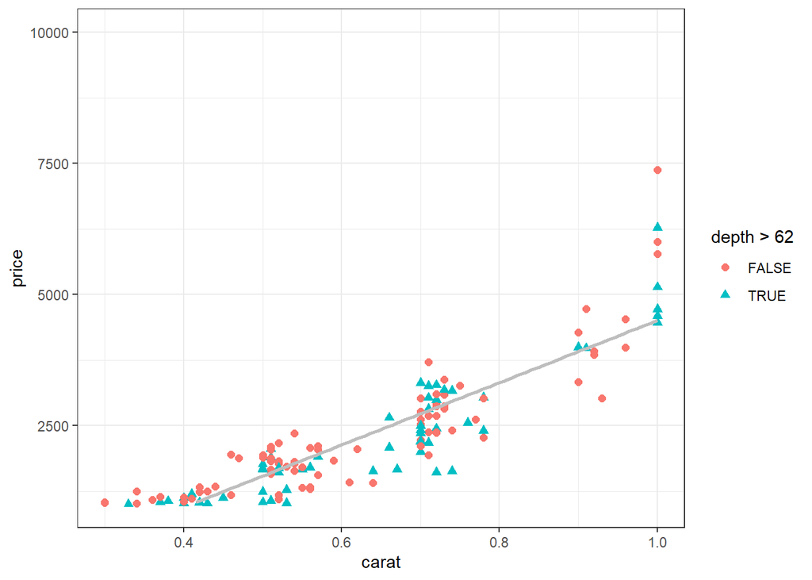

```r
p10 +
  lims(x = c(0.3, 1), y = c(1000, 10000))
```

# 6 different models regression

## exp

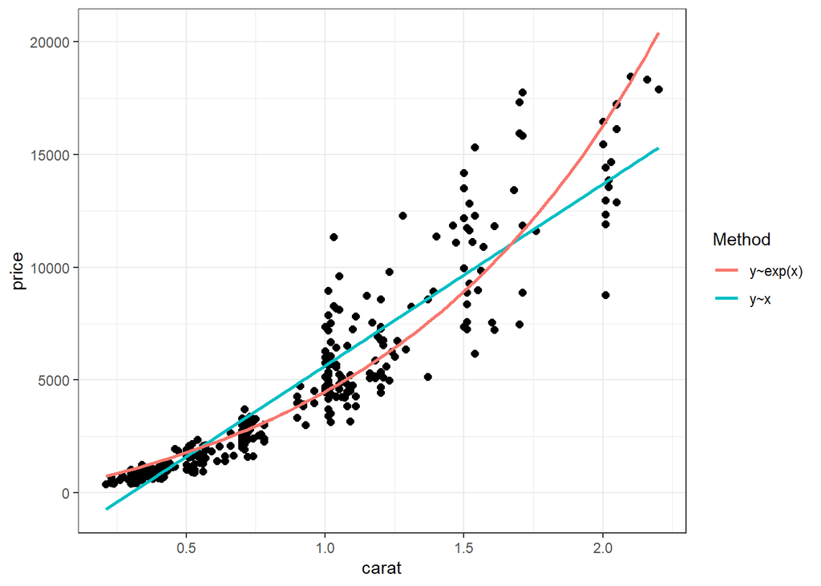

```r
p1 +
  geom_smooth(method = "lm", se = FALSE, aes(col = "y~x")) +
  geom_smooth(method = "lm", formula = y ~ exp(x), se = FALSE, aes(col = "y~exp(x)")) +
  labs(col = "Method")
```

# 7 barplot

## easy one

16. Create a barplot showing the *proportion* of each `cut`.

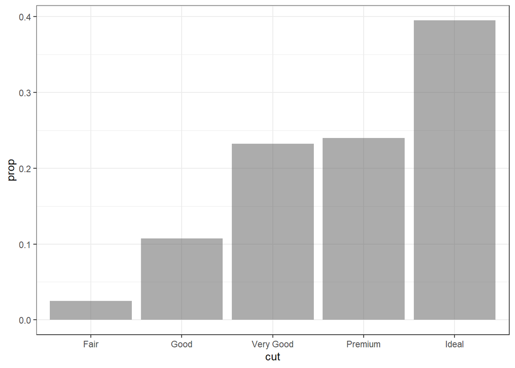

```r
# Method 1

p16 <- ggplot(diamonds2, aes(x = cut)) +
  geom_bar(alpha = 0.5, aes(y = ..count../sum(..count..))) +
  labs(y = "prop")
p16
```

## other method

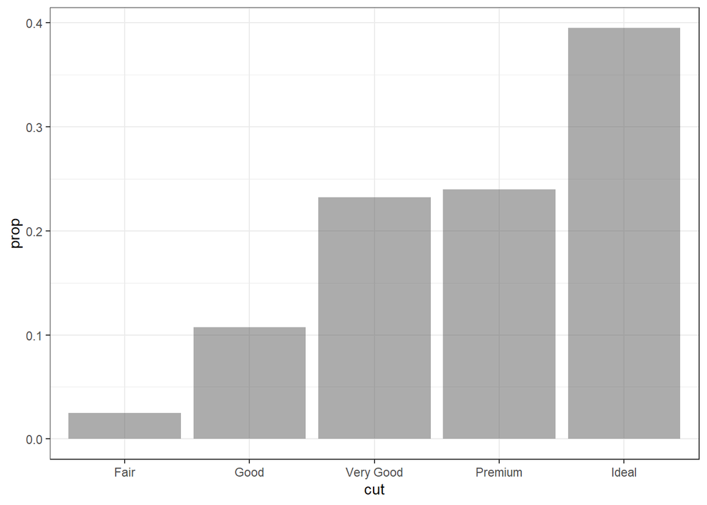

```r
# Method 2

tb <- xtabs(~cut, data = diamonds2) |>
  proportions() |>
  data.frame()

ggplot(tb, aes(x = cut, y = Freq)) +
  geom_col(alpha = 0.5) +
  labs(y = "prop")
```

## Bining

17. Create the variable $priceC=1 \times I(price \le 1040) +2 \times I(1040 < price \le 3300) + 3 \times I(price>3300)$. Make two barplots showing the proportion/percentage of each category of `price` per `cut` class. Do your best to get exactly the same figures as below. Hint: You may need to use the base R functions `cut()`, `xtabs()` and `proportions()` and the ggplot functions `geom_col()` and `geom_text()`.

```r
diamonds2$priceC <- cut(diamonds2$price, c(-Inf, 1040, 3300, Inf), labels = 1:3)
```

## barplot empilé

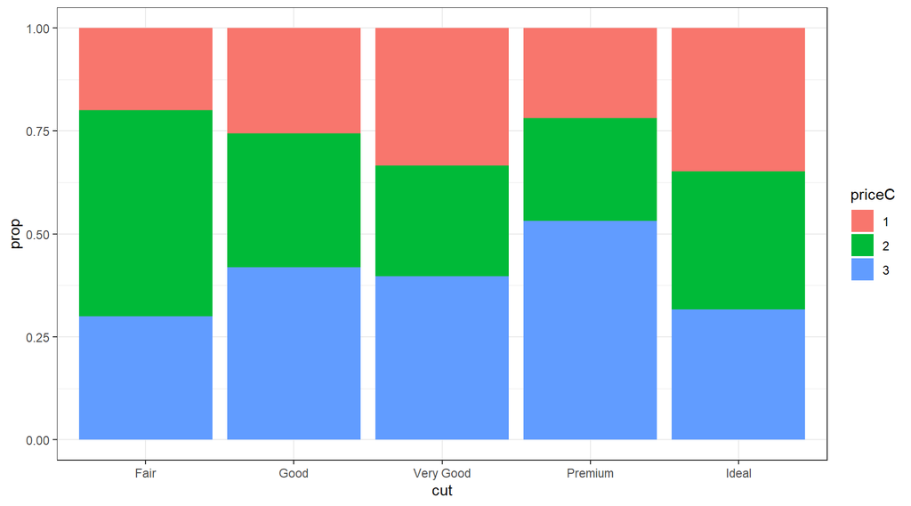

```r
# Plot 1

ggplot(data = diamonds2) +
  geom_bar(mapping = aes(x = cut, fill = priceC), position = "fill") +
  labs(y = "prop")
```

## barplot by categories

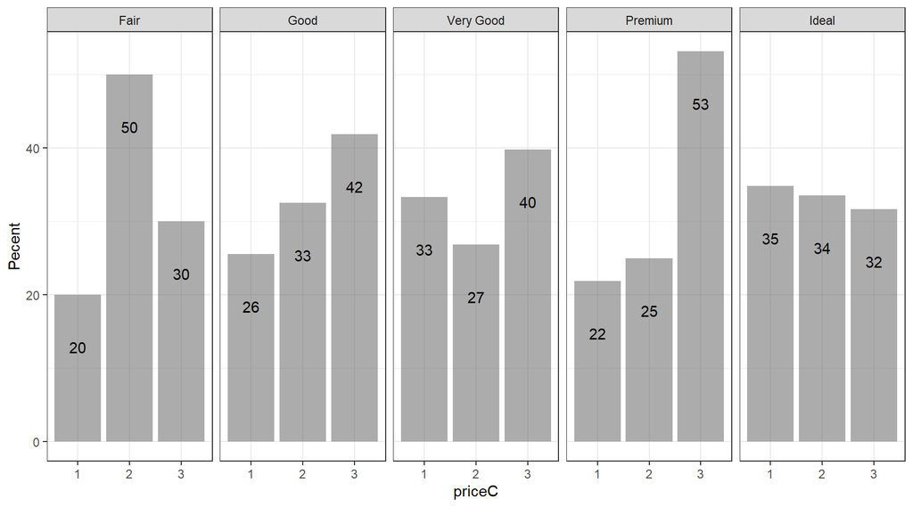

```r
# Plot 2

tb2 <- xtabs(~ priceC + cut, data = diamonds2) |>
  proportions("cut") |>
  data.frame()

ggplot(tb2, aes(x = priceC, y = Freq*100)) +
  geom_col(alpha = 0.5) +
  facet_grid(cols = vars(cut)) +
  geom_text(aes(label = round(Freq*100,0)), vjust = 5) +
  labs(y = "Pecent")
```

# 8 Comparison with other function

## add a normal density

18. We would like to examine the distribution of $log(price)$. More precisely, we would like to see, graphically, if a normal assumption is reasonable. To do so, you are asked to overlay a normal density curve (with the empirical mean and the empirical standard deviation) to the histogram of this variable. The resulting figure should look like this.

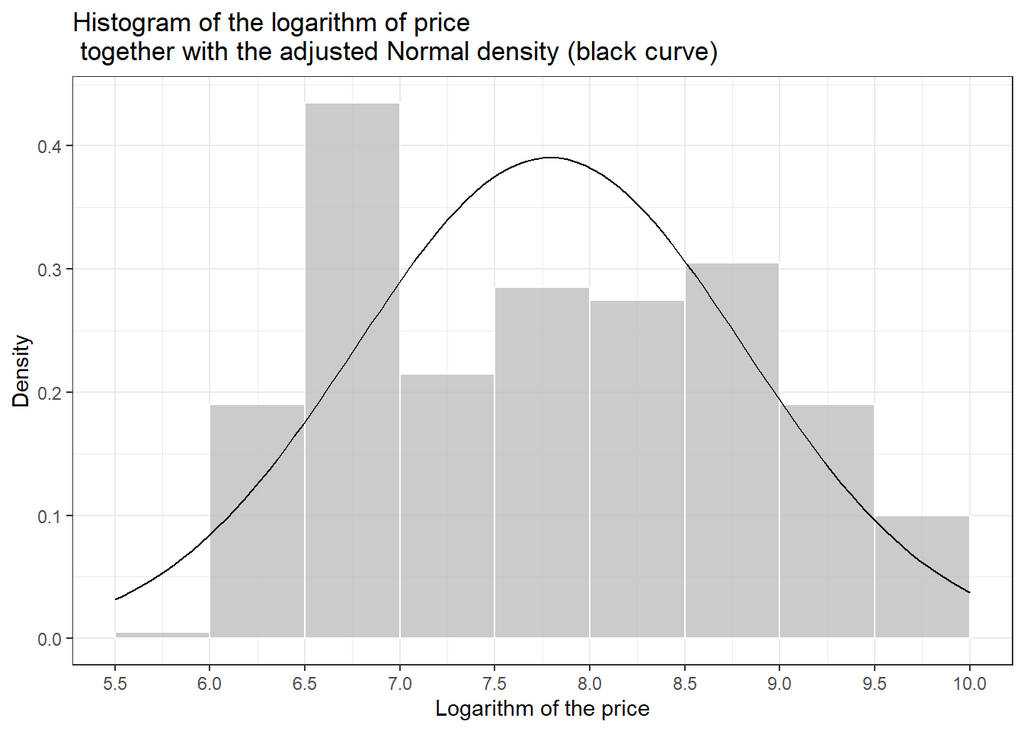

```r
lprice <- log(diamonds2$price)
m.lprice <- mean(lprice)
s.lprice <- sd(lprice)
lpbreaks <- lprice |> pretty(nclass.Sturges(lprice))

ggplot(diamonds2) +
  aes(x = log(price)) +
  geom_histogram(aes(y = ..density..), fill = "gray", alpha = 0.8, col = "white", breaks = lpbreaks) +
  stat_function(fun = dnorm, aes(y = log(price)), args = list(mean = m.lprice, sd = s.lprice), xlim = c(5.5, 10)) +
  scale_x_continuous(breaks = lpbreaks) +
  labs(x = "Logarithm of the price", y = "Density", title = "Histogram of the logarithm of price \n together with the adjusted Normal density (black curve)")
```

## add normal CDF

19. The same question as before but, this time, use the cumulative distribution function (CDF) instead of the density. Hint: Use the `ggplot2` function `stat_ecdf()`.

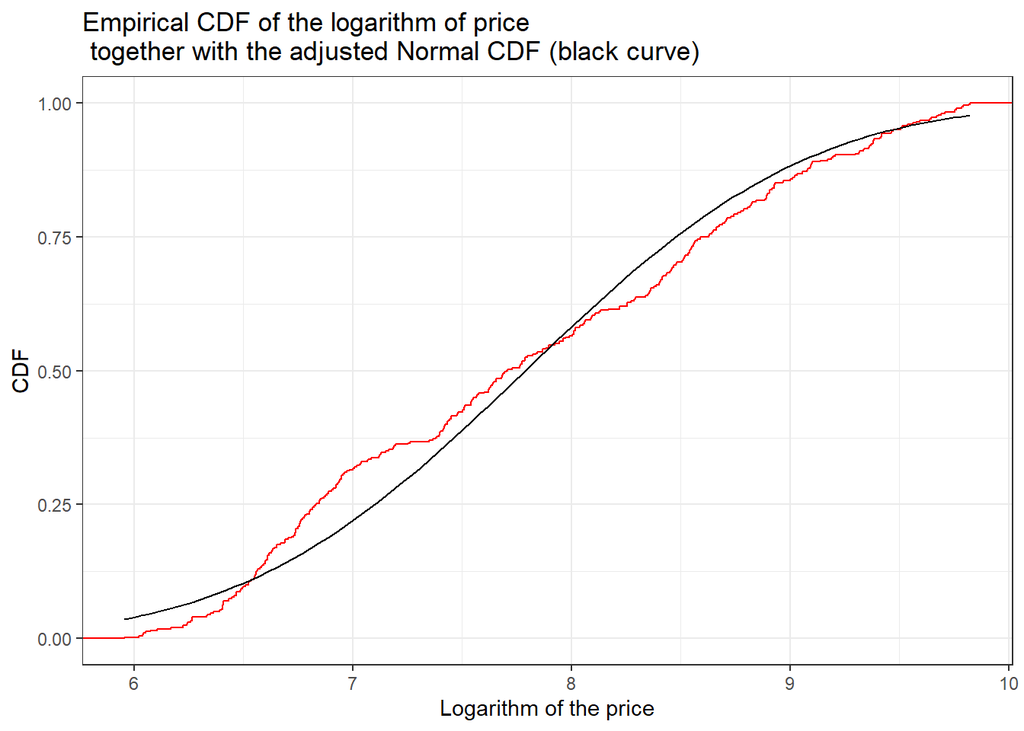

```r
ggplot(diamonds2) +
  aes(x = log(price)) +
  stat_ecdf(geom = "step", col = "red") +
  stat_function(fun = pnorm, aes(y = log(price)), args = list(mean = m.lprice, sd = s.lprice)) +
  labs(x = "Logarithm of the price", y = "CDF", title = "Empirical CDF of the logarithm of price \n together with the adjusted Normal CDF (black curve)")
```

# 9 boite a moustaches

## easy one

20. Now, we would like to study the distribution of `price` in each category of `cut`. Do so by making the following plot.

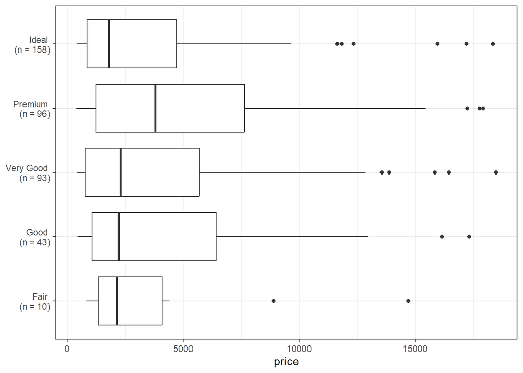

```r
p20 <- ggplot(diamonds2, aes(y = price, x = cut)) +
  geom_boxplot(varwidth = F) +
  coord_flip() +
  scale_x_discrete(labels = c("Fair \n (n = 10)", "Good \n (n = 43)", "Very Good \n (n = 93)", "Premium \n (n = 96)", "Ideal \n (n = 158)")) +
  labs(x = NULL)
p20
```

## relou one

21. The same question as before but, this time, you are asked to reproduce this plot.

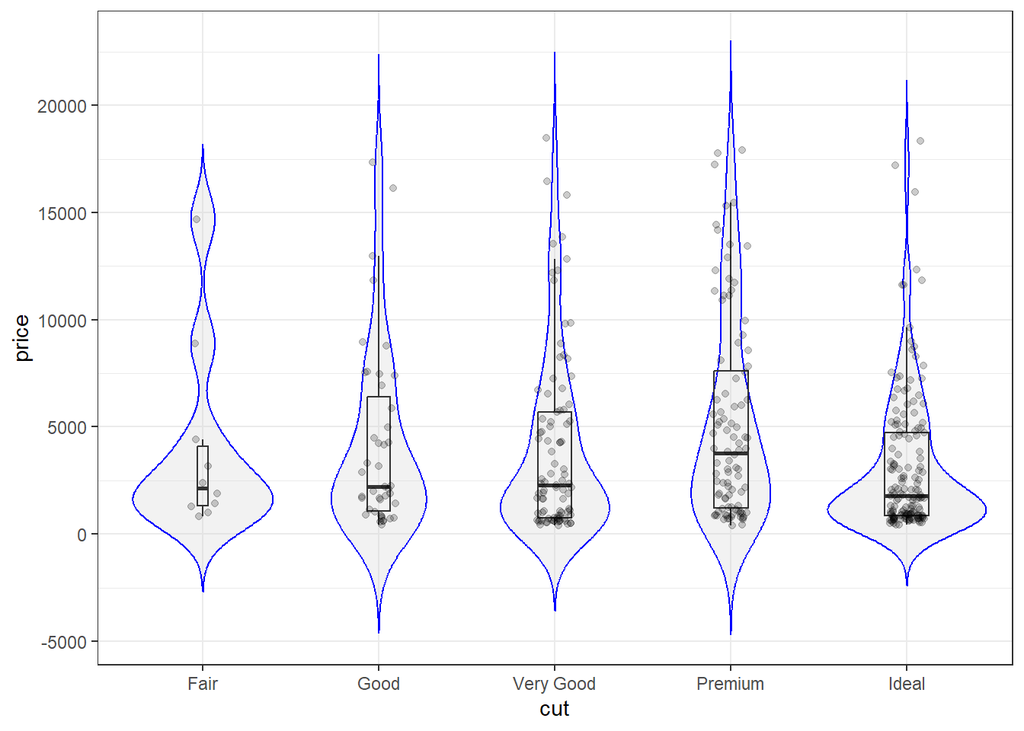

```r
# diamonds2$cut |> table()
p21 <- ggplot(diamonds2, aes(y = price, x = cut)) +
  geom_violin(color = 'blue', fill = "lightgray", alpha = 0.3, trim = FALSE) + # trim change un truc dans la forme des violons
  geom_boxplot(width = 0.25, varwidth = TRUE, outlier.shape = NA, fill = NA) +
  geom_jitter(width = 0.1, height = 0, alpha = 0.2) #evite l'overlap des points
p21
```

# 10 truc trop beau

22. Use the functions `ggplot::geom_qq()` and `ggplot::geom_qq_line()` and the package `patchwork` to produce a single plot that shows a box-plot, a density-plot and a qq-plot of `price` by `cut`.

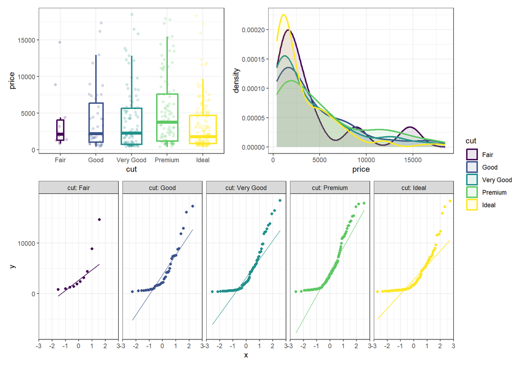

```r
p22.a <- ggplot(diamonds2, aes(x = cut, y = price, col = cut)) +
  geom_boxplot(varwidth = TRUE, size = 1, outlier.shape = NA) +
  geom_jitter(width = 0.2, alpha = 0.2) +
  theme(legend.position = "none")

p22.b <- ggplot(diamonds2, aes(x = price, fill = cut, col = cut)) +
  geom_density(alpha = 0.1, size = 1)

p22.c <- ggplot(diamonds2, aes(sample = price, col = cut), size = 2) +
  geom_qq() +
  geom_qq_line() +
  facet_grid(cols = vars(cut), labeller = label_both) +
  theme(legend.position = "none")

((p22.a + p22.b) / p22.c) + plot_layout(guides = "collect")
```